# FFXIV Player Behaviour and Party Finder Activity

## Introduction: What is this data about?

This visual data story explores Final Fantasy XIV player behaviour, focusing on:

- when players log in
- what content they engage with
- Party Finder activity patterns
- differences between raiders and non-raiders

The dataset comes from a player survey and reflects a snapshot of in-game behaviour.

## Most Common FFXIV Activities

This plot shows the distribution of different types of gameplay content engaged in by players.

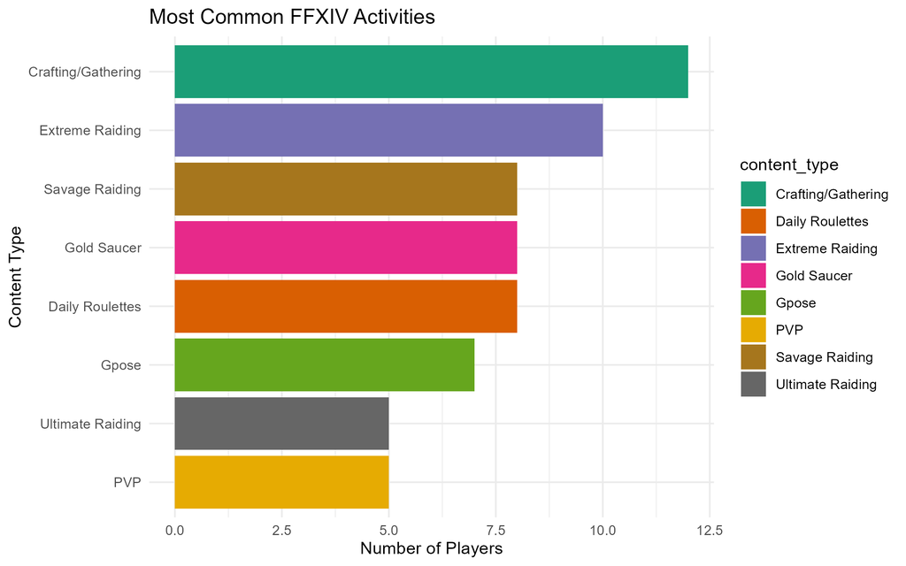

Crafting/Gathering tends to be the most popular activity, as it’s a type of content that both casual players can engage in, whilst also being a necessity for raiders to obtain equipment and food/potions for raiding content. This is followed Extreme and savage raiding, as they tend to be viewed as “midcore” content that presents a solid challenge whilst not being as daunting as hardcore content such as ultimate raids.

## Daily Playtime by Login Period

This visualisation compares hours played per day across different login times.

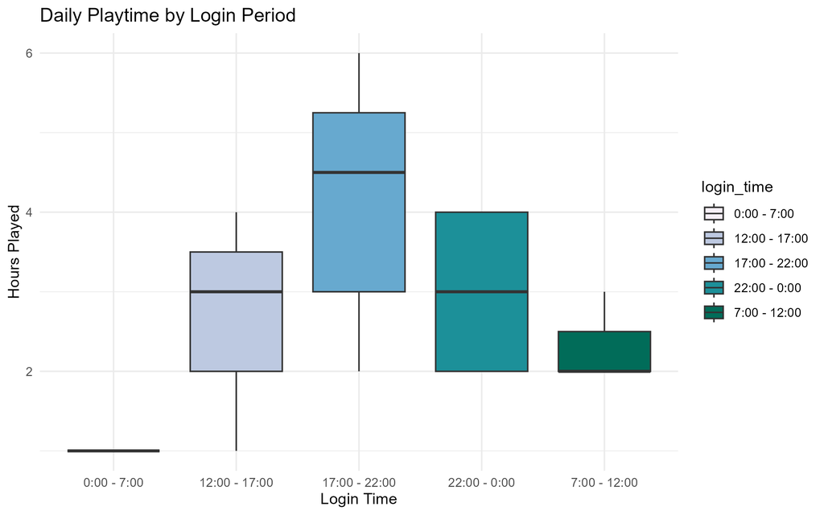

Evening players tend to have higher daily playtime. This follows as the target demographic of FFXIV (and MMORPGs on the whole) tend to be over the age of 18, where most people are busy with either their studies, or are already employed and cannot game during the work. This is most obvious when considering the vast majority of players tend to log on after 5pm, which is usually when their working hours finishes. I hypothesize that most people that log on during the mornings will not be able to find many other people to fill their parties when tackling content, so they will often only play for short periods and engage in short form content intended for small groups or solos.

## Party Finder Activity Breakdown

This chart shows what content is most commonly seen in Party Finder after logging in.

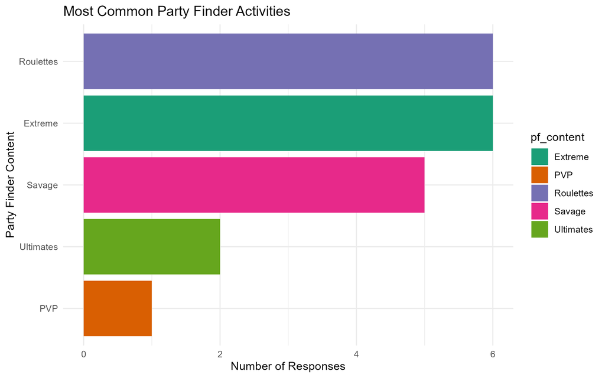

Savage and Extreme content still remain highly active in Party Finder, most likely due to the fact that they require 8 players for a full raid party, unlike crafting which can be done solo. Roulettes are also quite active in party finder, and this is probably due to roulettes being the primary source of battle content for non-raiders, and most solo casual players will engage with them in their play sessions. Ultimate and PVP are much less popular, and this is probably associated with the queue times needed to find enough people willing to tackle these types of content.

## Raiders vs Non-Raiders

This plot compares how many players engage in raiding content vs other gameplay styles.

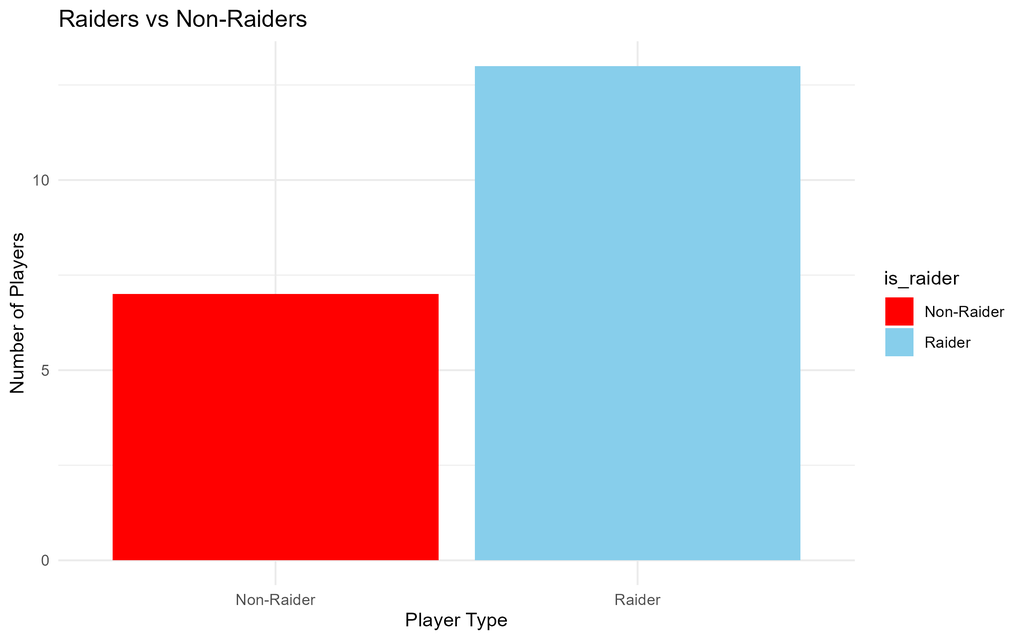

A significant portion of players engage in raiding content. This is most likely due to the fact that FFXIV requires all players to have at least one battle job levelled to progress through the main story quest (MSQ), and it follows that regular players will naturally have a battle job that can participate in raiding content. However, there are still a large portion of players that do not engage with raiding content at all, and these players probably engage in the content types that most raiders would ignore, such as the gold saucer minigames.

## Conclusion

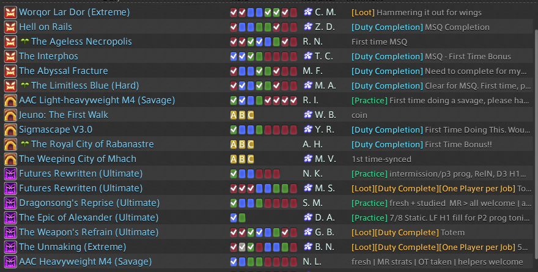

This provides a clear picture of how different types of players interact with the game environment.